**Machine Learning for Mechanical Engineering**  
**Midterm Exam - Part 2**  
**Thursday, 04/14/2023, 08:40~11:10 PM**

By Prof. Seungchul Lee  
http://iai.postech.ac.kr/  
Industrial AI Lab at POSTECH

# Problem 1

Jessica has been working on formulating the temperature (= $y$) of a semiconductor these days. She discovered that a semiconductor's temperature was related to the distance between atoms (= $x$). She assumed that the temperature of a semiconductor had an exponential relationship with the distance between atoms (i.e., $\exp(x)$). She also assumed that the temperature of the semiconductor had a periodic relationship with the distance between atoms (i.e., $\sin(x)$ or $\cos(x)$). Therefore, she tries to formulate the semiconductor temperature with a linear combination of $\sin(x)$, $\cos(x)$ and $\exp(x)$.

(a) [5pt] Formulate the temperature of semiconductor ($y$) from the given distance between atoms ($x$) using (nonlinear) regression.

$$ y = \theta_0 + \theta_1 \exp(x) + \theta_2 \sin(x) + \theta_3 \cos(x)$$

```python
import numpy as np
import matplotlib.pyplot as plt
import cvxpy as cvx

x = np.linspace(-5,5,30)
y = np.array([15.16043501, 14.93790538, 14.3694888, 13.52210637, 12.49552255,
              11.41059962, 10.39506827, 9.56848955, 9.02817864, 8.8377477,
              9.01961664, 9.55237357, 10.37329569, 11.38573378, 12.47049097,
              13.49985608, 14.35263938, 14.92844055, 15.15946909, 15.01852543,
              14.52220321, 13.72893569, 12.73211624, 11.64910292, 10.60740159,
              9.72965436, 9.1192006, 8.84791056, 8.94772391, 9.40688936])
```

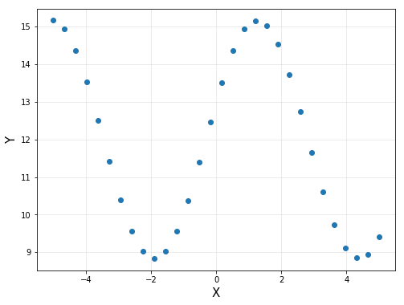

```python
plt.figure(figsize = (8,6))
plt.plot(x, y, 'o', label = "Data")
plt.xlabel("X", fontsize = 15)
plt.ylabel("Y", fontsize = 15)
plt.grid(alpha = 0.3)
plt.show()
```

```python
m = np.shape(x)[0]
x = np.reshape(x,(-1,1))
y = np.reshape(y,(-1,1))

## write your code here to get coefficients of regression (theta)
#
```

(b) [2pt] Plot your regression function in the range of `xp` below.

```python
xp = np.linspace(-5,5,30).reshape(-1,1)

## write down your code
yp =

plt.figure(figsize = (8,6))
plt.plot(x, y, 'o', label = "Data")
plt.plot(xp, yp, 'r')
plt.xlabel("X", fontsize = 15)
plt.ylabel("y", fontsize = 15)
plt.grid(alpha = 0.3)
plt.show()
```

(c) [2pt] Discuss the reason why the coefficient of $\exp(x)$ is much smaller than others.

```python
## Write down you reason
#
```

(d) [2pt] Jessica finds that if the distance of atom is 8, the temperature of semiconductor is 14.822. Evaluate your model whether it can predict outside the range of training dataset using the following metric.

$$\left\lvert \frac{y_{\text{true}} - y_{\text{pred}}}{y_{\text{true}}} \right\rvert \times 100$$

```python
y_true = 14.822
xp = 8

## write your code here
yp =
```

(e) [5pt] Peterson was also curious about the relationship between semiconductor temperature and atomic distance. Peterson opted to use polynomial regression to determine the link between two variables. Conduct polynomial regression again with a degree of 7 polynomial basis functions.

$$\hat y = \theta_0 + \theta_1 x + \cdots + \theta_7 x^7$$

```python
import numpy as np
import matplotlib.pyplot as plt
import cvxpy as cvx

x = np.linspace(-5,5,30)
y = np.array([15.16043501, 14.93790538, 14.3694888, 13.52210637, 12.49552255,
              11.41059962, 10.39506827, 9.56848955, 9.02817864, 8.8377477,
              9.01961664, 9.55237357, 10.37329569, 11.38573378, 12.47049097,
              13.49985608, 14.35263938, 14.92844055, 15.15946909, 15.01852543,
              14.52220321, 13.72893569, 12.73211624, 11.64910292, 10.60740159,
              9.72965436, 9.1192006, 8.84791056, 8.94772391, 9.40688936])

m = np.shape(x)[0]
x = np.reshape(x,(-1,1))
y = np.reshape(y,(-1,1))

## write down your code to get coefficients of polynomial regression (theta)
#
```

(f) [2pt] Plot your polynomial linear regression function using the range of $xp$ below.

```python
xp = np.linspace(-5,5,30).reshape(-1,1)

## write down your code
yp =

plt.figure(figsize = (8,6))
plt.plot(x, y, 'o',label = "Data")
plt.plot(xp, yp, 'r')
plt.xlabel("X", fontsize = 15)
plt.ylabel("y", fontsize = 15)
plt.grid(alpha = 0.3)
plt.show()
```

(g) [2pt] Peterson also found that if the distance of atom is 8, the temperature of semiconductor is 14.822. Evaluate your model whether it can predict outside the range of training dataset using the following metric.

$$\left\lvert \frac{y_{\text{true}} - y_{\text{pred}}}{y_{\text{true}}} \right\rvert \times 100$$

```python
y_true = 14.822
xp = 8

## write your code here
#
```

(h) [2pt] Discuss the two models in terms of generalization.

```python
## Write down your own reason using cell or text
#
```

# Solution 1

Jessica has been working on formulating the temperature (= $y$) of a semiconductor these days. She discovered that a semiconductor's temperature was related to the distance between atoms (= $x$). She assumed that the temperature of a semiconductor had an exponential relationship with the distance between atoms (i.e., $\exp(x)$). She also assumed that the temperature of the semiconductor had a periodic relationship with the distance between atoms (i.e., $\sin(x)$ or $\cos(x)$). Therefore, she tries to formulate the semiconductor temperature with a linear combination of $\sin(x)$, $\cos(x)$ and $\exp(x)$.

(a) [5pt] Formulate the temperature of semiconductor ($y$) from the given distance between atoms ($x$) using (nonlinear) regression.

$$ y = \theta_0 + \theta_1 \exp(x) + \theta_2 \sin(x) + \theta_3 \cos(x)$$

```python
import numpy as np
import matplotlib.pyplot as plt
import cvxpy as cvx

x = np.linspace(-5,5,30)

# y= 3*np.sin(x)+np.cos(x)+12
y = np.array([15.16043501, 14.93790538, 14.3694888, 13.52210637, 12.49552255,
              11.41059962, 10.39506827, 9.56848955, 9.02817864, 8.8377477,
              9.01961664, 9.55237357, 10.37329569, 11.38573378, 12.47049097,
              13.49985608, 14.35263938, 14.92844055, 15.15946909, 15.01852543,
              14.52220321, 13.72893569, 12.73211624, 11.64910292, 10.60740159,
              9.72965436, 9.1192006, 8.84791056, 8.94772391, 9.40688936])

plt.figure(figsize = (10,8))
plt.plot(x,y,'o',label = "Data")
plt.xlabel("X",fontsize = 15)
plt.ylabel("Y",fontsize = 15)
plt.grid(alpha = 0.3)
plt.show()
```

[output not shown]

```python
m = np.shape(x)[0]
x = np.reshape(x,(-1,1))
y = np.reshape(y,(-1,1))

#write your code here
A = np.hstack([x**0, np.exp(x), np.sin(x), np.cos(x)])
A = np.asmatrix(A)
y = np.asmatrix(y)
theta = np.ones([10,1])
theta = (A.T*A).I*A.T*y
print(theta)
```

```
[[ 1.20000000e+01]
 [-1.67932196e-11]
 [ 3.00000000e+00]
 [ 9.99999999e-01]]
```

(b) [2pt] Plot your regression function in the range of `xp` below.

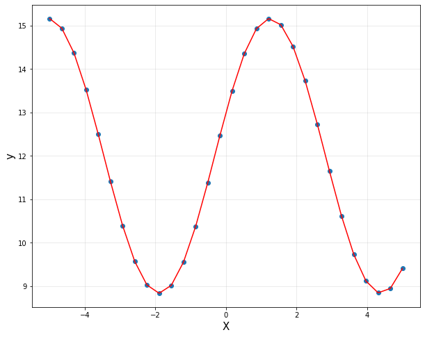

```python
xp = np.linspace(-5,5,30).reshape(-1,1)

yp = theta[0,0] + theta[1,0]*np.exp(xp)+theta[2,0]*np.sin(xp)+theta[3,0]*np.cos(x)

plt.figure(figsize = (8,6))
plt.plot(x, y, 'o', label = "Data")
plt.plot(xp, yp, 'r')
plt.xlabel("X", fontsize = 15)
plt.ylabel("y", fontsize = 15)
plt.grid(alpha = 0.3)
plt.show()
```

(c) [2pt] Discuss the reason why the coefficient of $\exp(x)$ is much smaller than others.

The exponential characteristic of this regression is much smaller than the periodic characteristic.

(d) [2pt] Jessica finds that if the distance of atom is 8, the temperature of semiconductor is 14.822. Evaluate your model whether it can predict outside the range of training dataset using the following metric.

$$\left\lvert \frac{y_{\text{true}} - y_{\text{pred}}}{y_{\text{true}}} \right\rvert \times 100$$

```python
# about the abs
abs(-1)
```

```
1
```

```python
y_true = 14.822
xp = 8
# write your code here
yp = theta[0,0] + theta[1,0]*np.exp(xp)+theta[2,0]*np.sin(xp)+theta[3,0]*np.cos(xp)
abs(((yp-y_true)/y_true))*100
```

```
0.003877045525003203
```

(e) [5pt] Peterson was also curious about the relationship between semiconductor temperature and atomic distance. Peterson opted to use polynomial regression to determine the link between two variables. Conduct polynomial regression again with a degree of 7 polynomial basis functions.

$$\hat y = \theta_0 + \theta_1 x + \cdots + \theta_7 x^7$$

```python
import numpy as np
import matplotlib.pyplot as plt
import cvxpy as cvx

x = np.linspace(-5,5,30)
y = np.array([15.16043501, 14.93790538, 14.3694888, 13.52210637, 12.49552255,
              11.41059962, 10.39506827, 9.56848955, 9.02817864, 8.8377477,
              9.01961664, 9.55237357, 10.37329569, 11.38573378, 12.47049097,
              13.49985608, 14.35263938, 14.92844055, 15.15946909, 15.01852543,
              14.52220321, 13.72893569, 12.73211624, 11.64910292, 10.60740159,
              9.72965436, 9.1192006, 8.84791056, 8.94772391, 9.40688936])

m = np.shape(x)[0]
x = np.reshape(x,(-1,1))
y = np.reshape(y,(-1,1))

B = np.hstack([x**i for i in range(7)])
B = np.asmatrix(B)
y = np.asmatrix(y)
theta = np.ones([10,1])

theta = (B.T*B).I*B.T*y
print(theta)
```

```
[[ 1.29664035e+01]
 [ 2.54787633e+00]
 [-4.51534179e-01]
 [-3.31227920e-01]
 [ 3.06877594e-02]
 [ 8.35858874e-03]
 [-5.50768675e-04]]
```

(f) [2pt] Plot your polynomial linear regression function using the range of `xp` below.

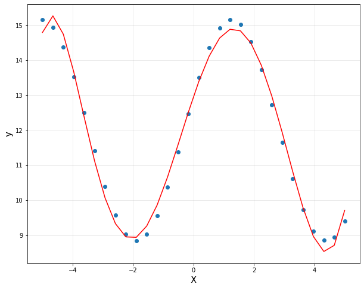

```python
xp = np.linspace(-5,5,30).reshape(-1,1)
yp = theta[0,0] + theta[1,0]*xp+theta[2,0]*xp**2+theta[3,0]*xp**3+theta[4,0]*xp**4+theta[5,0]*xp**5+theta[6,0]*xp**6

plt.figure(figsize = (8,6))
plt.plot(x, y, 'o',label = "Data")
plt.plot(xp, yp, 'r')
plt.xlabel("X", fontsize = 15)
plt.ylabel("y", fontsize = 15)
plt.grid(alpha = 0.3)
plt.show()
```

$$\left\lvert \frac{y_{\text{true}} - y_{\text{pred}}}{y_{\text{true}}} \right\rvert \times 100$$

```python
# about the abs
abs(-1)
```

```
1
```

```python
y_true = 14.822
xp = 8

# write your code here
yp = theta[0,0] + theta[1,0]*xp+theta[2,0]*xp**2+theta[3,0]*xp**3+theta[4,0]*xp**4+theta[5,0]*xp**5+theta[6,0]*xp**6
print(abs(((yp-y_true)/y_true))*100)
```

```
507.6988681611548
```

(h) [2pt] Discuss the two models in terms of generalization.

Jessica's model have generalization because it can predict extrapolation very well. However, Peterson's model is overfitted in the range of training dataset.

# Problem 2

(a) [4pt] We would like to use the SVM algorithm to classify the blue and red circles as shown below. Find weights of a SVM model using cvxpy. (i.e., Find $\omega$ in $\omega^Tx = 0$)

Download files ([data x](https://www.dropbox.com/s/il0n4fvxu5ch902/x.npy?dl=1) and [data y](https://www.dropbox.com/s/fvh89baa8ndteg3/y.npy?dl=1))

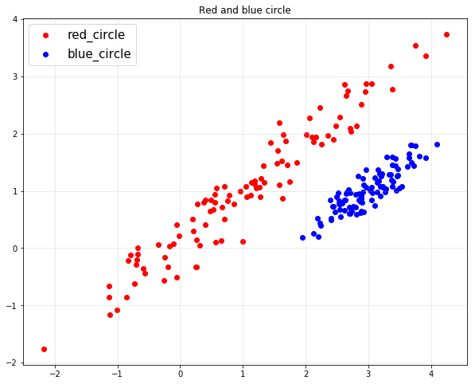

```python
import numpy as np
import matplotlib.pyplot as plt
import cvxpy as cvx

d = 2     # Dimension is 2
m = 100   # The number of points in each class
n = 100
x = np.load("./data_files/x.npy")
y = np.load("./data_files/y.npy")

plt.figure(figsize = (10,8))
plt.grid(alpha = 0.3)
plt.title("Red and blue circle")
plt.scatter(x[:,0], x[:,1], color = 'red', label = "red_circle")
plt.scatter(y[:,0], y[:,1], color = 'blue', label = "blue_circle")
plt.legend(fontsize = 15)
plt.show()
```

(b) [2pt] Plot a decision boundary. Note that your graph also includes red and blue circles.

```python
## write down your code here
#
```

# Solution 2

(a) [4pt] We would like to use the SVM algorithm to classify the blue and red circles as shown below. Find weights of a SVM model using cvxpy. (i.e., Find $\omega$ in $\omega^Tx = 0$)

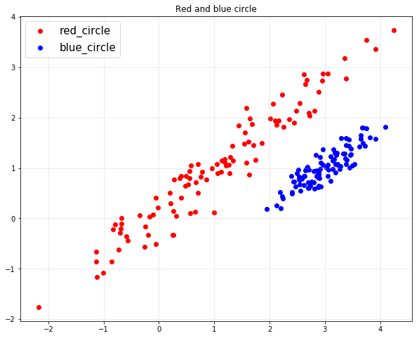

```python
import numpy as np
import matplotlib.pyplot as plt
import cvxpy as cvx

d = 2     # Dimension is 2
m = 100   # Number of points in each class
n = 100

x = np.load("./data_files/x.npy")
y = np.load("./data_files/y.npy")

plt.figure(figsize = (10,8))
plt.grid(alpha = 0.3)
plt.title("Red and blue circle")
plt.scatter(x[:,0], x[:,1], color = 'red', label = "red_circle")
plt.scatter(y[:,0], y[:,1], color = 'blue', label = "blue_circle")
plt.legend(fontsize = 15)
plt.show()
```

```python
x = np.hstack([np.ones([m,1]),x])
y = np.hstack([np.ones([m,1]),y])

g = 1

w = cvx.Variable((d+1,1))
u = cvx.Variable((m, 1))
v = cvx.Variable((m, 1))
obj = cvx.Minimize(cvx.norm(w, 2) + g*(np.ones([1, 100])*u + np.ones([1, 100])*v))
const = [x*w >= 1-u, y*w <= -(1-v), u >= 0, v >= 0 ]
prob = cvx.Problem(obj, const).solve()

w = w.value
print(w)
```

```
[[ 2.69106563]
 [-2.28535748]
 [ 2.21684148]]
```

(b) [2pt] Plot a decision boundary. Note that your graph also includes red and blue circles.

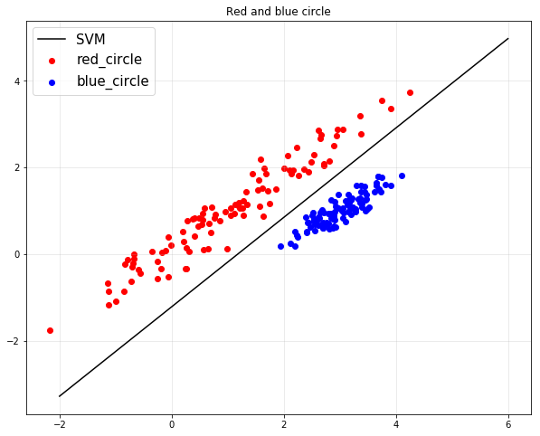

```python
xp = np.linspace(-2,6,100)
yp = - w[1,0]/w[2,0]*xp - w[0,0]/w[2,0]

plt.figure(figsize = (10,8))
plt.grid(alpha = 0.3)
plt.title("Red and blue circle")
plt.scatter(x[:,1], x[:,2], color = 'red', label = "red_circle")
plt.scatter(y[:,1], y[:,2], color = 'blue', label = "blue_circle")
plt.plot(xp, yp, c = 'k', label = 'SVM')
plt.legend(fontsize = 15)
plt.show()
```